# Into the Tidyverse

Session One Exercises

Remember, before you can use the tidyverse, you need to load the package.

```r
library(tidyverse)
```

## First Steps

### Plots with the iris dataset

1. Take a look at the `iris` dataset. What are its dimensions? What do its columns represent?
2. What are the ranges of each of the numeric columns. The `summary()` function might help you here
3. Make a plot of sepal width vs sepal length, and set all of the points to be green
4. Repeat the previous plot but colour each point by the species of the flower

## More Aesthetics

### Size, Transparency, and Shape

1. Using the `mpg` dataset, make a plot of city mileage vs highway mileage where the size of each point is determined by engine size (`displ`)
2. Plot sepal length vs sepal width using the `iris` dataset and control the transparency (`alpha`) of each point using the `species` variable.
3. Have a play with the `Orange` data set (note the capital ‘O’). Make a scatter plot of circumference against age where the shape of each point is determined by which tree the observation belongs to
4. Remake the standard `hwy` vs `displ` plot using the `mpg` data set but make all of the points hollow diamonds. How about solid triangles?

### Choosing Appropriate Aesthetics

(**Q1/2 form R4DS**)

1. Which variables in `mpg` are categorical? Which are continuous/discrete? (The data set help file may be of use)
2. Map a continuous variable to colour, size, and shape. How does this differ from when you map a categorical variable?
3. Plot the standard `hwy` vs `displ` graph using `mpg` and map the variable `class` to the `size` aesthetic. Was this a good idea?
4. Which of the aesthetics you know are the clearest for displaying categorical data and which are best for continuous?
5. In your own opinion, order the following aesthetics by how clear they are in representing a continuous variable: size, colour, transparency

### Common Problems

1. Using the `mpg` data set, make a plot of city milage against engine size. Map the variable `class` to the aesthetic `shape`. Is everything as you would expect?
2. Type the following code into the console. Why do you recieve an error message?

```r
library(ggplot2)
ggplot(data = iris) +
  geom_point(x = Sepal.Length, y = Petal.Length)
```

3. Take a look at the `airquality` dataset. Type the following code into the console. Is the plot as you expected?

```r
ggplot(airquality) +
  geom_point(aes(x = Wind, y = Temp, col = Month))
```

4. Why are the points in this plot not blue?

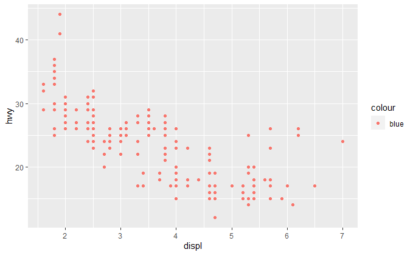

```r
ggplot(data = mpg) +
  geom_point(mapping = aes(x = displ, y = hwy, colour = 'blue'))
```

5. What happens when you map a variable to multiple aesthetics (say colour and size)? (It’s okay to answer, “nothing”, to this question but make sure you verify that first!)

## Facetting

### Basic Faceting

(**Taken form R4DS**)

1. What happens when you facet a continuous variable?
2. What do the empty cells in a plot with `facet_grid(drv ~ cyl)` mean? How do they relate to this plot?

```r
ggplot(data = mpg) +
  geom_point(mapping = aes(x = drv, y = cyl))
```

3. What plots does the following code make? What does the `.` do?

```r
ggplot(data = mpg) +
  geom_point(mapping = aes(x = displ, y = hwy)) +
  facet_grid(drv ~ .)

ggplot(data = mpg) +
  geom_point(mapping = aes(x = displ, y = hwy)) +
  facet_grid(. ~ cyl)
```

4. Take the first faceted plot from the presentation:

```r
ggplot(data = mpg) +
  geom_point(mapping = aes(x = displ, y = hwy)) +
  facet_grid(~ class, nrow = 2)
```

What advantages of faceting instead of the colour aesthetic? What are the disadvantages? How might the balance change if you had a larger data set?

5. Read `?facet_wrap`. What does `nrow` do? What does `ncol` do? What other options control the layout of the individual panels? Why doesn’t `facet_grid()` have `nrow` and `ncol` parameters?
6. When using `facet_grid()` you should usually put the variable with more unique levels in the columns. Why?

### Combining Facets with Aesthetics

1. Using the `mpg` dataset, plot `hwy` vs `cty`, map `displ` to the `size` aesthetic, map `class` to point colour, and facet columns by `cyl` and rows by `drv`. This plot is ridiculous but it does demonstrate the flexibilty of `ggplot2`

## Going Beyond

### Labelling

1. Run the following code. What does the extra `labs(...)` layer do?

```r
ggplot(data = mpg) +
  geom_point(aes(x = displ, y = hwy, colour = class)) +
  labs(x = "Engine Displacment (litres)", y = "Highway Milage (miles/gallon)",
       colour = "Car Type",
       title = "A scatter plot of engine displacment vs highway milage",
       subtitle = "Coloured by car type",
       caption = "Source: EPA (http://fueleconomy.gov)")
```

### Diamonds and Overplotting

1. Have a look at the `diamonds` dataset
2. Make a scatter plot of `price` against `caret` (this may take a long time to run). Is this plot easy to read?
3. How could you fix this problem? (perhaps you could manually set a certain aesthetic)

### Explanatory and Response variables

1. How do you decide which variable to map to the x-axis and which to plot to the y-axis?
2. If you are unsure, web-search for the phrase “explanatory and response variables”

### Positional Arguments

Begin with the following code

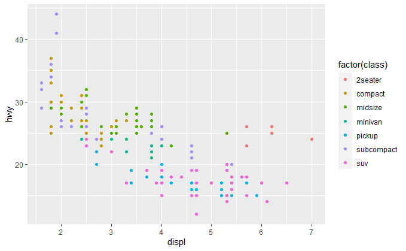

```r
ggplot(data = mpg) +
  geom_point(mapping = aes(x = displ, y = hwy, colour = factor(class)))
```

1. Try removing `data =` from your `ggplot` call. Does everything still work?
2. Try removing `mapping =` from your `geom_point` call. Does everything still work?
3. Try removing `x =` and `y =` from your `geom_point` call. Does everything still work?
4. Try removing `colour =` from your `geom_point` call. Does everything still work?
5. Take the original plot and specify the aesthetics in a different order, say `y` then `colour` then `x`. Does everything still work?